# Project 2 on Machine Learning, deadline November 10 (Midnight)

**[Data Analysis and Machine Learning FYS-STK3155/FYS4155](http://www.uio.no/studier/emner/matnat/fys/FYS3155/index-eng.html)**, University of Oslo, Norway

Date: **October 14, 2025**

## Deliverables

First, join a group in canvas with your group partners. Pick an avaliable group for Project 2 in the **People** page.

In canvas, deliver as a group and include:

- A PDF of your report which follows the guidelines covered below and in the week 39 exercises. Additional requirements include:
  - It should be around 5000 words, use the word counter in Overleaf for this. This often corresponds to 10-12 pages. References and appendices are excluded from the word count
  - It should include around 10-15 figures. You can include more figures in appendices and/or as supplemental material in your repository.
- A comment linking to your github repository (or folder in one of your github repositories) for this project. The repository must include

A PDF file of the report

- A folder named Code, where you put python files for your functions and notebooks for reproducing your results. Remember to use a seed for generating random data and for train-test splits when generating final results.
- A README file with the name of the group members
- a short description of the project
- a description of how to install the required packages to run your code from a requirements.txt file or similar (such as a plain text description) names and descriptions of the various notebooks in the Code folder and the results they produce

### Preamble: Note on writing reports, using reference material, AI and other tools

We want you to answer the three different projects by handing in reports written like a standard scientific/technical report. The links at https://github.com/CompPhysics/MachineLearning/tree/master/doc/Projects contain more information. There you can find examples of previous reports, the projects themselves, how we grade reports etc. How to write reports will also be discussed during the various lab sessions. Please do ask us if you are in doubt.

When using codes and material from other sources, you should refer to these in the bibliography of your report, indicating wherefrom you for example got the code, whether this is from the lecture notes, softwares like Scikit-Learn, TensorFlow, PyTorch or other sources. These sources should always be cited correctly. How to cite some of the libraries is often indicated from their corresponding GitHub sites or websites, see for example how to cite Scikit-Learn at https://scikit-learn.org/dev/about.html.

We enocurage you to use tools like ChatGPT or similar in writing the report. If you use for example ChatGPT, please do cite it properly and include (if possible) your questions and answers as an addition to the report. This can be uploaded to for example your website, GitHub/GitLab or similar as supplemental material.

If you would like to study other data sets, feel free to propose other sets. What we have proposed here are mere suggestions from our side. If you opt for another data set, consider using a set which has been studied in the scientific literature. This makes it easier for you to compare and analyze your results. Comparing with existing results from the scientific literature is also an essential element of the scientific discussion. The University of California at Irvine with its Machine Learning repository at https://archive.ics.uci.edu/ml/index.php is an excellent site to look up for examples and inspiration. Kaggle.com is an equally interesting site. Feel free to explore these sites.

## Classification and Regression, writing our own neural network code

The main aim of this project is to study both classification and regression problems by developing our own feed-forward neural network (FFNN) code. The exercises from week 41 and 42 (see https://compphysics.github.io/MachineLearning/doc/LectureNotes/_build/html/exercisesweek41.html and https://compphysics.github.io/MachineLearning/doc/LectureNotes/_build/html/exercisesweek42.html) as well as the lecture material from the same weeks (see https://compphysics.github.io/MachineLearning/doc/LectureNotes/_build/html/week41.html and https://compphysics.github.io/MachineLearning/doc/LectureNotes/_build/html/week42.html) should contain enough information for you to get started with writing your own code.

We will also reuse our codes on gradient descent methods from project 1.

The data sets that we propose here are (the default sets)

- Regression (fitting a continuous function). In this part you will need to bring back your results from project 1 and compare these with what you get from your Neural Network code to be developed here. The data sets could be
  - The simple one-dimensional function Runge function from project 1, that is $f(x) = \frac{1}{1+25x^2}$. We recommend using a simpler function when developing your neural network code for regression problems. Feel however free to discuss and study other functions, such as the two-dimensional Runge function $f(x,y)=\left[(10x - 5)^2 + (10y - 5)^2 + 1 \right]^{-1}$, or even more complicated two-dimensional functions (see the supplementary material of https://www.nature.com/articles/s41467-025-61362-4 for an extensive list of two-dimensional functions).
- Classification.
- We will consider a multiclass classification problem given by the full MNIST data set. The full data set is at https://www.kaggle.com/datasets/hojjatk/mnist-dataset.

We will start with a regression problem and we will reuse our codes on gradient descent methods from project 1.

### Part a): Analytical warm-up

When using our gradient machinery from project 1, we will need the expressions for the cost/loss functions and their respective gradients. The functions whose gradients we need are:

1. The mean-squared error (MSE) with and without the $L_1$ and $L_2$ norms (regression problems)
2. The binary cross entropy (aka log loss) for binary classification problems with and without $L_1$ and $L_2$ norms
3. The multiclass cross entropy cost/loss function (aka Softmax cross entropy or just Softmax loss function)

Set up these three cost/loss functions and their respective derivatives and explain the various terms. In this project you will however only use the MSE and the Softmax cross entropy.

We will test three activation functions for our neural network setup, these are the

1. The Sigmoid (aka **logit**) function,
2. the RELU function and
3. the Leaky RELU function

Set up their expressions and their first derivatives. You may consult the lecture notes (with codes and more) from week 42 at https://compphysics.github.io/MachineLearning/doc/LectureNotes/_build/html/week42.html.

### Reminder about the gradient machinery from project 1

In the setup of a neural network code you will need your gradient descent codes from project 1. For neural networks we will recommend using stochastic gradient descent with either the RMSprop or the ADAM algorithms for updating the learning rates. But you should feel free to try plain gradient descent as well.

We recommend reading chapter 8 on optimization from the textbook of Goodfellow, Bengio and Courville at https://www.deeplearningbook.org/. This chapter contains many useful insights and discussions on the optimization part of machine learning. A useful reference on the back progagation algorithm is Nielsen's book at http://neuralnetworksanddeeplearning.com/.

You will find the Python [Seaborn package](https://seaborn.pydata.org/generated/seaborn.heatmap.html) useful when plotting the results as function of the learning rate $\eta$ and the hyper-parameter $\lambda$ .

### Part b): Writing your own Neural Network code

Your aim now, and this is the central part of this project, is to write your own FFNN code implementing the back propagation algorithm discussed in the lecture slides from week 41 at https://compphysics.github.io/MachineLearning/doc/LectureNotes/_build/html/week41.html and week 42 at https://compphysics.github.io/MachineLearning/doc/LectureNotes/_build/html/week42.html.

We will focus on a regression problem first, using the one-dimensional Runge function

$$ f(x) = \frac{1}{1+25x^2}, $$

from project 1.

Use only the mean-squared error as cost function (no regularization terms) and write an FFNN code for a regression problem with a flexible number of hidden layers and nodes using only the Sigmoid function as activation function for the hidden layers. Initialize the weights using a normal distribution. How would you initialize the biases? And which activation function would you select for the final output layer? And how would you set up your design/feature matrix? Hint: does it have to represent a polynomial approximation as you did in project 1?

Train your network and compare the results with those from your OLS regression code from project 1 using the one-dimensional Runge function. When comparing your neural network code with the OLS results from project 1, use the same data sets which gave you the best MSE score. Moreover, use the polynomial order from project 1 that gave you the best result. Compare these results with your neural network with one and two hidden layers using $50$ and $100$ hidden nodes, respectively.

Comment your results and give a critical discussion of the results obtained with the OLS code from project 1 and your own neural network code. Make an analysis of the learning rates employed to find the optimal MSE score. Test both stochastic gradient descent with RMSprop and ADAM and plain gradient descent with different learning rates.

You should, as you did in project 1, scale your data.

```python
# General-purpose FFNN moved to p2_nn_module.py for reuse
# Import the neural network components instead of defining them inline.
from p2_nn_module import FFNN, one_hot, ActivationName, LossName, RegName, OptName

import numpy as np
from typing import List, Optional, Dict, Any
```

### Experiments

Now it is time to run the experiments. We will focus on a regression problem first, using the one-dimensional Runge function $$ f(x) = \frac{1}{1+25x^2}, $$

```python
# Generate dataset with 1D runge function, split, and scale
import numpy as np
from sklearn.model_selection import train_test_split
from sklearn.preprocessing import StandardScaler
import p2_nn_module as p2

# Reproducible 1D inputs in [-1, 1]
n_samples = 500
x = np.linspace(-1.0, 1.0, n_samples).reshape(-1, 1)

# Runge targets
y = p2.runge(x.ravel()).reshape(-1, 1)

# Train/test split
X_train, X_test, y_train, y_test = train_test_split(x, y, test_size=0.2, random_state=42)

# Scale features and targets (recommended for NN training)
x_scaler = StandardScaler().fit(X_train)
y_scaler = StandardScaler().fit(y_train)

X_train_s = x_scaler.transform(X_train)
X_test_s = x_scaler.transform(X_test)
y_train_s = y_scaler.transform(y_train)
y_test_s = y_scaler.transform(y_test)

print({'X_train': X_train.shape, 'X_test': X_test.shape, 'y_train': y_train.shape, 'y_test': y_test.shape})
```

```
{'X_train': (400, 1), 'X_test': (100, 1), 'y_train': (400, 1), 'y_test': (100, 1)}
```

### Model Architecture

Now we will use only the mean-squared error as cost function (no regularization terms) and use the FFNN code for a regression problem with a flexible number of hidden layers and nodes using only the Sigmoid function as activation function for the hidden layers. We initialize the weights using a normal distribution. We initialize the biases to be zero. Since we are performing a regression problem, we will chose the linear output layer and calculate the MSE loss. The design matrix Wx + b where W represents the weights. This does not need to represent a polynomial approximation in the way that OLS or Ridge does.

### Experiment: FFNN on Runge function

Here we train our network and compare the results with those from our OLS regression code from project 1 using the one-dimensional Runge function and polynomial degree 10. We will compare these results with your neural network with one and two hidden layers using $50$ and $100$ hidden nodes, respectively.

We will test both stochastic gradient descent with RMSprop and ADAM and plain gradient descent with different learning rates.

```
beta shape = (11, 1)
{'mse_train_scaled': 0.018882575880289913, 'mse_test_scaled': 0.01440908250981074}
```

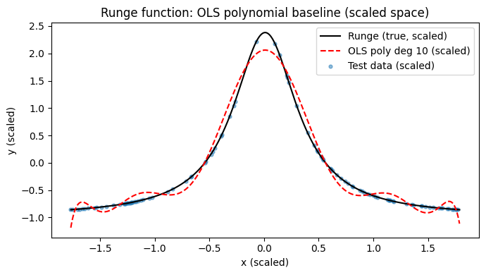

```python
# Baseline (scaled): OLS on Runge with polynomial features built on scaled x, predicting scaled y
import numpy as np
import matplotlib.pyplot as plt
import p2_nn_module as p2

# Polynomial degree (keep consistent with your Project 1 best)
degree = 10

# Build polynomial design matrices on the scaled train/test splits
X_train_poly = p2.polynomial_features(X_train_s.ravel(), degree)
X_test_poly  = p2.polynomial_features(X_test_s.ravel(), degree)

# Fit OLS parameters on scaled targets
beta = p2.OLS_parameters(X_train_poly, y_train_s)
print(f"beta shape = {beta.shape}")

# Predictions in scaled target space
y_train_pred_s = X_train_poly @ beta
y_test_pred_s  = X_test_poly  @ beta

# MSE in scaled space
mse_train_s = p2.MSE(y_train_s, y_train_pred_s)
mse_test_s  = p2.MSE(y_test_s,  y_test_pred_s)
print({"mse_train_scaled": mse_train_s, "mse_test_scaled": mse_test_s})

# Visualization in scaled space
# Prepare a dense grid in original x, then scale x and true y to the same space used for training
xx = np.linspace(-1.0, 1.0, 500).reshape(-1, 1)
xx_s = x_scaler.transform(xx)
Xx_poly = p2.polynomial_features(xx_s.ravel(), degree)
yy_true = p2.runge(xx.ravel()).reshape(-1, 1)
yy_true_s = y_scaler.transform(yy_true).ravel()
yy_ols_s  = (Xx_poly @ beta).ravel()

plt.figure(figsize=(7,4))
plt.plot(xx_s.ravel(), yy_true_s, 'k-', label='Runge (true, scaled)')
plt.plot(xx_s.ravel(), yy_ols_s,  'r--', label=f'OLS poly deg {degree} (scaled)')
plt.scatter(X_test_s.ravel(), y_test_s.ravel(), s=12, alpha=0.5, label='Test data (scaled)')
plt.xlabel('x (scaled)')
plt.ylabel('y (scaled)')
plt.title('Runge function: OLS polynomial baseline (scaled space)')
plt.legend()
plt.tight_layout()
plt.show()
```

### FFNN Runge experiments (scaled)

We train the flexible FFNN from above on the scaled Runge dataset using a grid over:

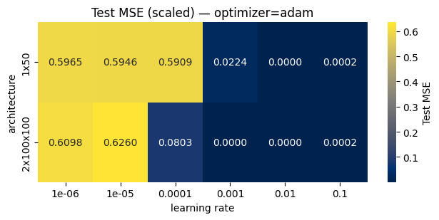

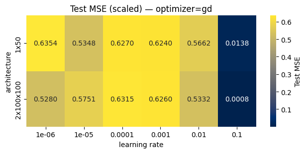

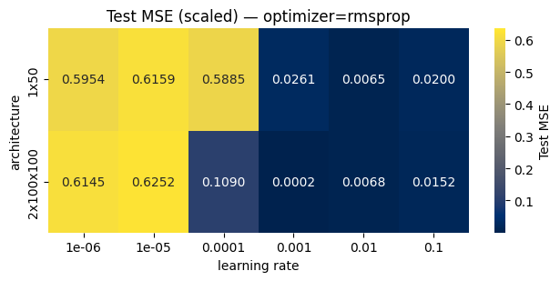

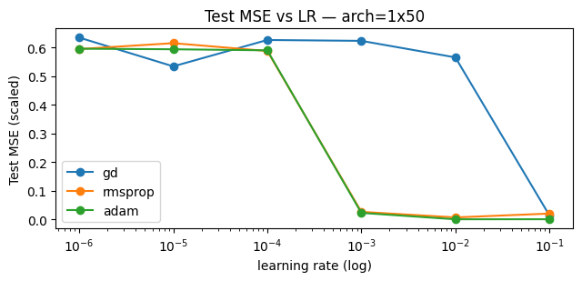

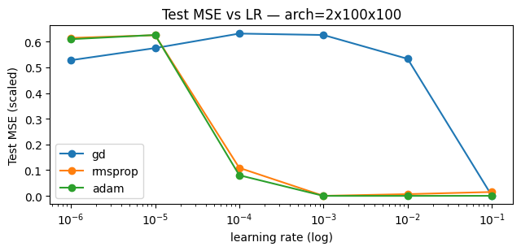

```
Top 5 configs by Test MSE (scaled):
{'arch': '2x100x100', 'optimizer': 'adam', 'lr': 0.001, 'mse_train': 1.0294359073746299e-05, 'mse_test': 9.615001312190721e-06, 'time_s': 8.077484999999797}
{'arch': '1x50', 'optimizer': 'adam', 'lr': 0.01, 'mse_train': 1.898481820080756e-05, 'mse_test': 1.3207268695738576e-05, 'time_s': 0.6087177999997948}
{'arch': '2x100x100', 'optimizer': 'adam', 'lr': 0.01, 'mse_train': 2.2077616509924707e-05, 'mse_test': 2.3183718207349704e-05, 'time_s': 8.124080199999298}
{'arch': '2x100x100', 'optimizer': 'rmsprop', 'lr': 0.001, 'mse_train': 0.00020008541373155077, 'mse_test': 0.00015922258458515848, 'time_s': 7.6850426999990304}
{'arch': '1x50', 'optimizer': 'adam', 'lr': 0.1, 'mse_train': 0.00016787725885024745, 'mse_test': 0.00016511120681286996, 'time_s': 0.636600300000282}
```

```python
# Grid experiments: architectures × optimizers × learning rates (scaled data) — refactored
# -------------------------------------------------------------------------------------------------
# This cell now calls helpers from p2_nn_module to:
# 1) Train the grid over (architecture, optimizer, LR),
# 2) Plot per-optimizer heatmaps, and
# 3) Plot LR curves per architecture and print the top-k configs by Test MSE.
# -------------------------------------------------------------------------------------------------

import importlib, numpy as np
import p2_nn_module as p2
importlib.reload(p2)

assert 'X_train_s' in globals() and 'y_train_s' in globals(), "Scaled dataset not found. Run data prep first."

# Experiment grid
architectures = [
    ("1x50",       [1, 50, 1],         ['sigmoid', 'linear']),
    ("2x100x100",  [1, 100, 100, 1],  ['sigmoid', 'sigmoid', 'linear']),
]
optimizers = ['gd', 'rmsprop', 'adam']
learning_rates = [1e-6, 1e-5, 1e-4, 1e-3, 1e-2, 1e-1]

# Training config
results = p2.run_arch_opt_lr_grid(
    X_train_s, y_train_s,
    X_test_s, y_test_s,
    architectures=architectures,
    optimizers=optimizers,
    learning_rates=learning_rates,
    epochs=300,
    batch_size=32,
    seed=42,
)

# Visualizations and summary
p2.plot_optimizer_heatmaps(results, architectures, learning_rates, cmap='cividis')
p2.plot_lr_curves(results, architectures, learning_rates, optimizers)
p2.print_top_k_results(results, k=5)
```